# Allele-specific ChiPseq analysis. Explore peaksets

Anastasiia Hryhorzhevska

# 3. Peaksets overlap rate

To determine which peaks are “valid”, we perform overlap peaksets analysis for each group (dex and veh) separately.

## 3.1. DEX group

47 consensus peaksets were identified for dex group, 37’757 of which is the total number of unique sites, 21’482 - the number of unique sites appearing in at least two peaksets, 16’679 - the number of sites overlapping in at least three peaksets, etc.

```r
or.dex <- dba.overlap(dba.db, dba.db$masks$dex, mode=DBA_OLAP_RATE)
or.dex
```

```
##  [1] 37757 21482 16679 13616 11128  9285  7674  6495  5523  4707  4062  3458
## [13]  3071  2731  2428  2180  1986  1832  1671  1519  1401  1307  1238  1156
## [25]  1085  1016   932   890   838   774   719   683   632   577   541   500
## [37]   459   419   385   343   306   278   242   216   184   139    93
```

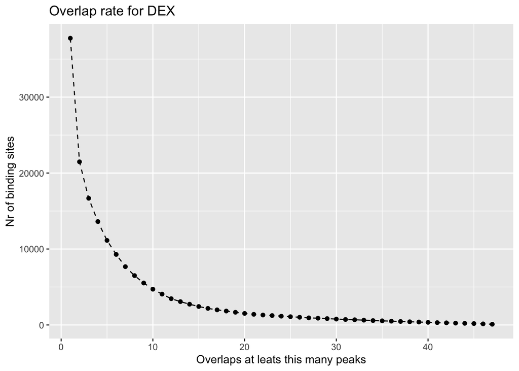

```r
ggplot(as.data.frame(or.dex), aes(y = or.dex, x = 1:length(or.dex))) +
  geom_line(linetype = "dashed")+
  geom_point() +
  ylab("Nr of binding sites") +
  xlab("Overlaps at leats this many peaks") +
  ggtitle("Overlap rate for DEX") +
  theme(legend.position = "bottom")
```

## 3.2. VEH group

```r
or.veh <- dba.overlap(dba.db, dba.db$masks$veh, mode=DBA_OLAP_RATE)
or.veh
```

```
##  [1] 21486  8772  5760  4118  3039  2287  1716  1346  1047   832   703   576
## [13]   478   426   386   336   307   281   251   224   208   188   180   175
## [25]   163   153   143   139   131   127   124   120   114   111   107   101
## [37]    98    97    93    90    87    80    77    75    72    67    62    53
```

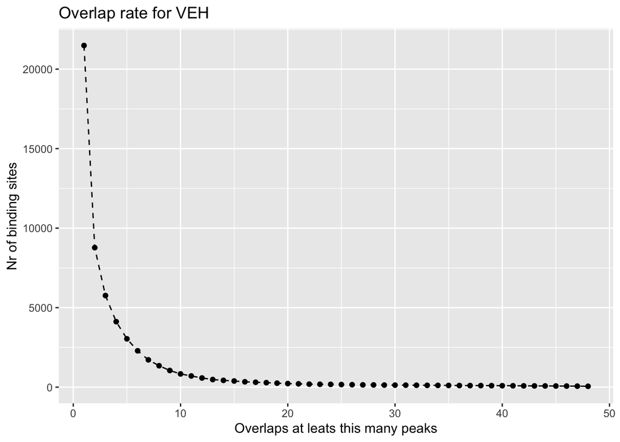

```r
ggplot(as.data.frame(or.veh), aes(y = or.veh, x = 1:length(or.veh))) +
  geom_line(linetype = "dashed")+
  geom_point() +
  ylab("Nr of binding sites") +
  xlab("Overlaps at leats this many peaks") +
  ggtitle("Overlap rate for VEH") +
  theme(legend.position = "bottom")
```

## 3.3. Create separate consensus peaksets for each of the two treatments (veh and dex)

### Requiring that consensus peaks overlap in at least 0% of the samples in each group results:

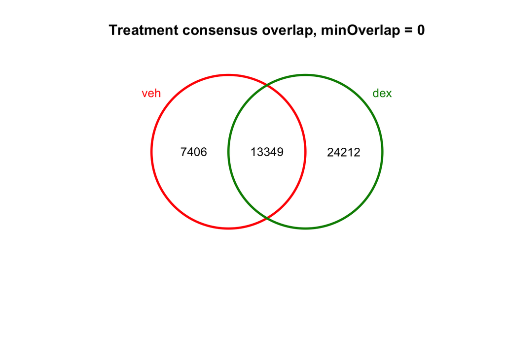

### Requiring that consensus peaks overlap in at least 10% of the samples in each group results:

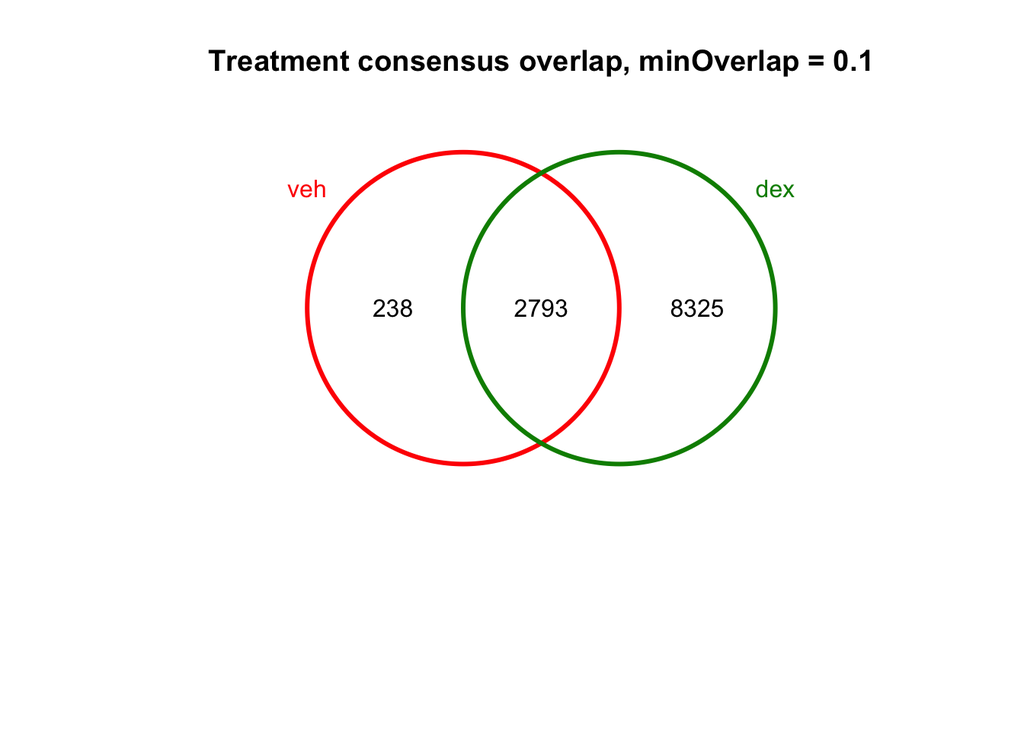

```r
dba.consensus.minolap.01 <- dba.peakset(dba.db, consensus = c(DBA_TREATMENT), minOverlap = 0.1)
dba.plotVenn(dba.consensus.minolap.01, dba.consensus.minolap.01$masks$Consensus, main = "Treatment consensus overlap, minOverlap = 0.1")
```

### Requiring that consensus peaks overlap in at least 20% of the samples in each group results:

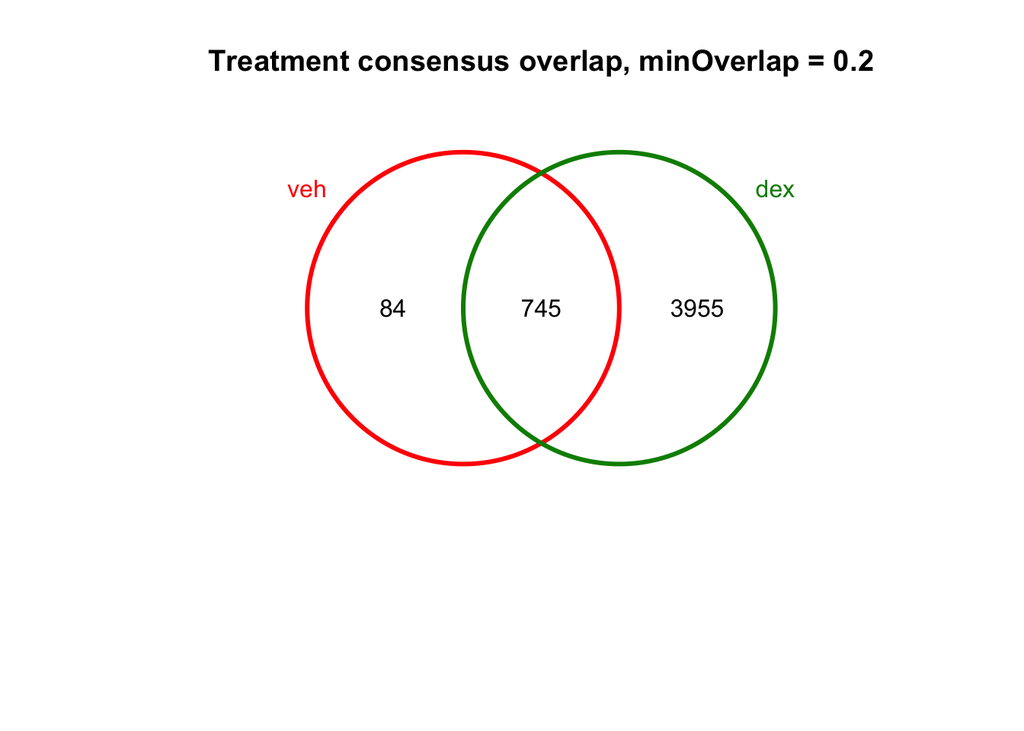

```r
dba.consensus.minolap.02 <- dba.peakset(dba.db, consensus = c(DBA_TREATMENT), minOverlap = 0.2)
dba.plotVenn(dba.consensus.minolap.02, dba.consensus.minolap.02$masks$Consensus, main = "Treatment consensus overlap, minOverlap = 0.2")
```

### Requiring that consensus peaks overlap in at least 30% of the samples in each group results:

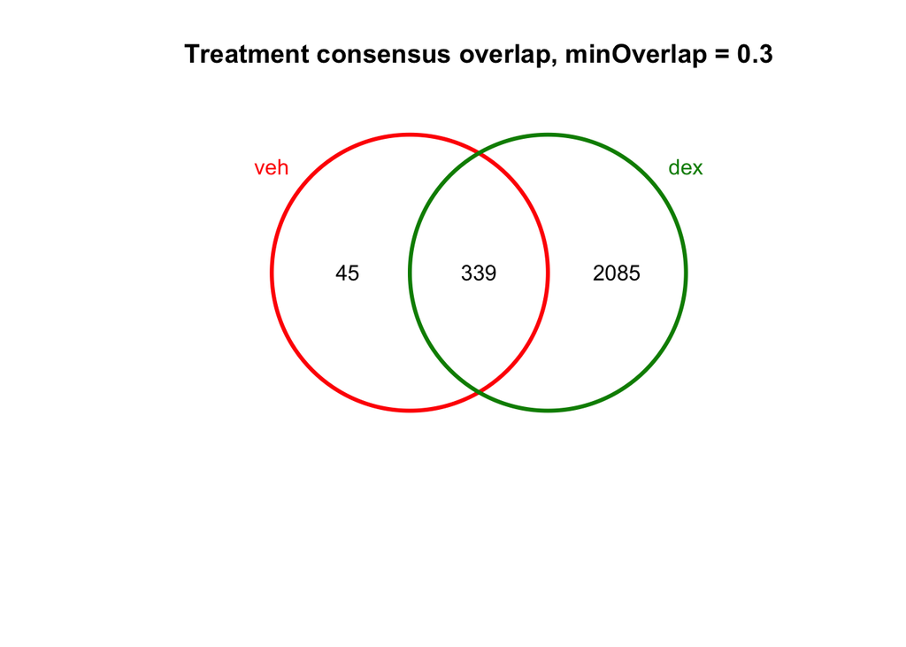

```r
dba.consensus.minolap.03 <- dba.peakset(dba.db, consensus = c(DBA_TREATMENT), minOverlap = 0.3)
dba.plotVenn(dba.consensus.minolap.03, dba.consensus.minolap.03$masks$Consensus, main = "Treatment consensus overlap, minOverlap = 0.3")
```

## 3.4. Explore peakssets

### 3.4.1. Explore DEX

#### 3.4.1.1. Mean, median, and max size of the peaks

```r
summary(width(grange.dex))
```

```
##    Min. 1st Qu.  Median    Mean 3rd Qu.    Max.
##     168     298     409     492     622    2391
```

#### 3.4.1.2. Distribution of peak sizes

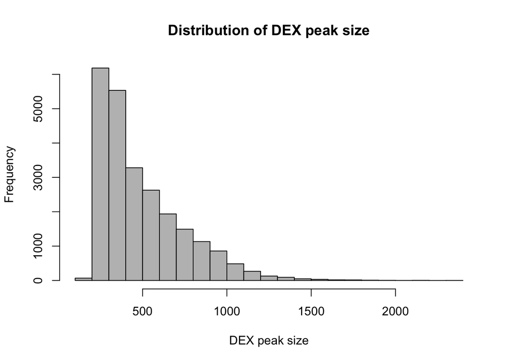

```r
hist(width(grange.dex), xlab = "DEX peak size", col = "gray", main = "Distribution of DEX peak size")
```

#### 3.4.1.3 Distribution of peak p-values

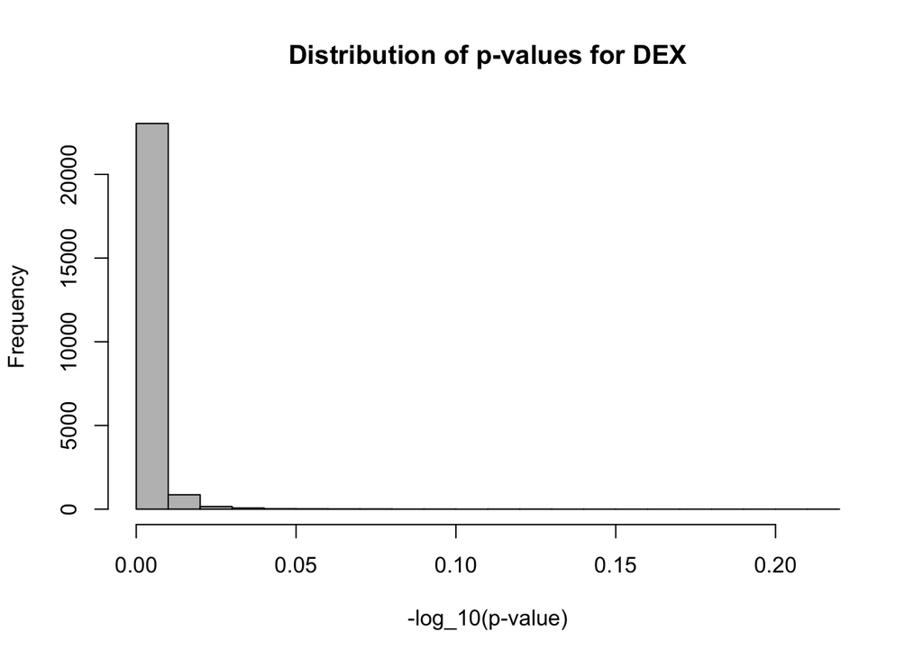

```r
p.values <- score(grange.dex)
hist(p.values, xlab = "-log_10(p-value)", col = "gray", main = "Distribution of p-values for DEX")
```

### 3.4.2. Explore VEH

#### 3.4.2.1. Mean, median, and max size of the peaks

```r
summary(width(grange.veh))
```

```
##    Min. 1st Qu.  Median    Mean 3rd Qu.    Max.
##   172.0   232.0   270.0   295.7   327.8  1643.0
```

#### 3.4.2.2. Distribution of peak sizes

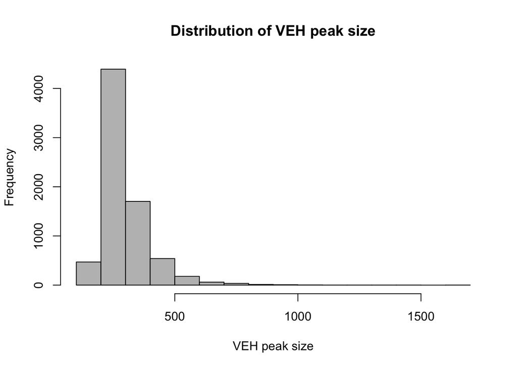

```r
hist(width(grange.veh), xlab = "VEH peak size", col = "gray", main = "Distribution of VEH peak size")
```

#### 3.4.1.3 Distribution of peak p-values

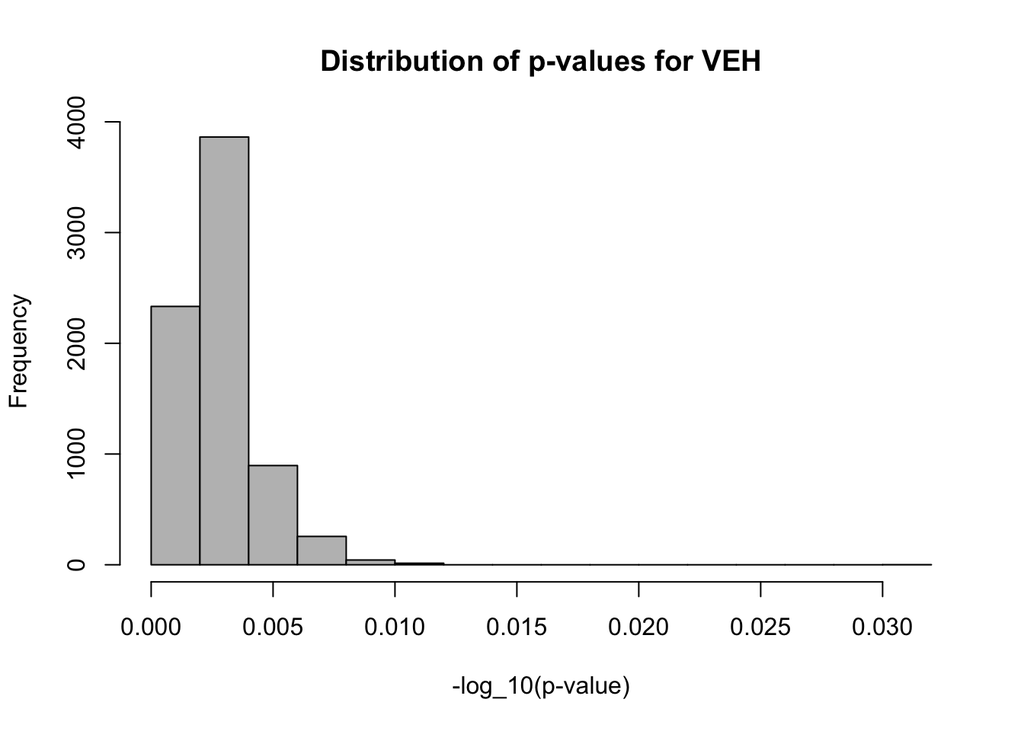

```r
p.values <- score(grange.veh)
hist(p.values, xlab = "-log_10(p-value)", col = "gray", main = "Distribution of p-values for VEH")
```

### 3.4.3. Explore OVERLAPs

#### 3.4.3.1. Mean, median, and max size of the peaks

```r
summary(width(grange.olap))
```

```
##    Min. 1st Qu.  Median    Mean 3rd Qu.    Max.
##   208.0   623.0   842.0   900.8  1099.0  5127.0
```

#### 3.4.3.2. Distribution of peak sizes

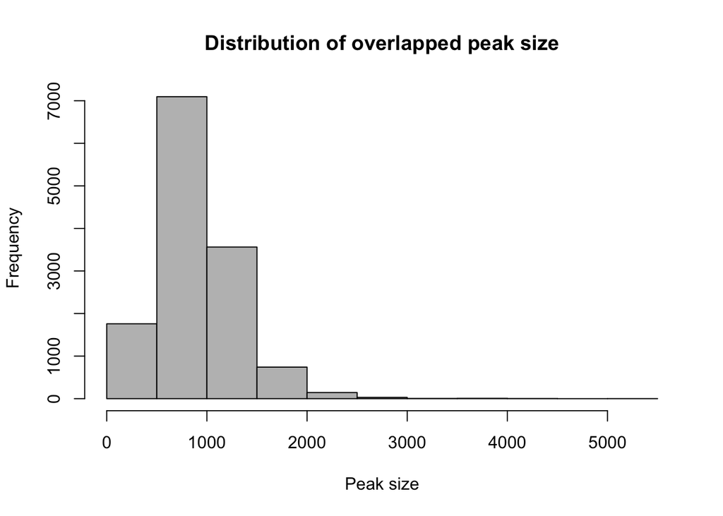

```r
hist(width(grange.olap), xlab = "Peak size", col = "gray", main = "Distribution of overlapped peak size")
```